# Econ 10R Part 4: Statistical Inference and Linear Regression

Luke Zhang

September 8, 2021

*This file contains all the materials on the topics of statistical inference and linear regression. It covers the classes from week 5 Tuesday to week 6 Tuesday (inclusive). Last update: September 8, 2021*

# 1 Estimation

In this part, we study the estimation of unknown parameters. Let us start by generating a dataset that we can think of as a random sample from a known population:

```r
set.seed(1)
v1 <- rnorm(20, mean = 14, sd = 5)
v1
```

```
##  [1] 10.867731 14.918217  9.821857 21.976404 15.647539  9.897658 16.437145
##  [8] 17.691624 16.878907 12.473058 21.558906 15.949216 10.893797  2.926501
## [15] 19.624655 13.775332 13.919049 18.719181 18.106106 16.969507
```

Here we have a dataset that is sampled from a normal distribution of mean 14 and standard deviation 5. What is a good estimator for the population mean assume that we do not know it? In this case, it is the sample mean:

```r
mean(v1)
```

```
## [1] 14.95262
```

What about the sample variance? Well, recall that the formula for the sample variance of the mean is given by the sample variance divided by $n-1$, we have

```r
var(v1)
```

```
## [1] 20.85081
```

Remember that R incorporates $n-1$ in `var` already. We can do a lot more estimation, but it is not very interesting right now compared to the estimation of linear models later. So let’s leave it there for now.

# 2 Hypothesis Testing

Based on the data, a test is a binary decision on a hypothesis: reject or not reject. Let’s conduct a hypothesis testing where the null hypothesis is $H_0: \mu=17$ against $H_1: \mu \neq 17$.

## 2.1 Step 1 Form the Test Statistic

Since we know that the sample is drawn from a normal distribution with a known variance, we know under the null the test statistic is of the following form:

$$\frac{\bar{X}-17}{5/\sqrt{20}} \sim N(0, 1)$$

We can compute the test statistic here:

```r
test <- (mean(v1)-17)/sqrt(25/20)
test
```

```
## [1] -1.831233
```

## 2.2 Step 2 Derive the $p$ value

We can compute the $p$ value in R directly using the `pnorm` function:

```r
p_value <- pnorm(test, lower.tail = TRUE) + pnorm(-test, lower.tail = FALSE)
p_value
```

```
## [1] 0.06706579
```

## 2.3 Step 3 Compare to the Significance Level

Now we need to choose a significance level $\alpha$ to make a comparison. If the $p$ value is smaller than $\alpha$, we will reject the null hypothesis. Otherwise, we do not reject the null. Generally we use 5%, so by this standard, we do not reject the null hypothesis. This does not seem like a good result, as we know 17 is not the true mean.

## 2.4 Sample Size

The problem here is that we have a small sample with a large variance. Let’s increase the sample size and try again:

```r
v2 <- rnorm(100, mean = 14, sd = 5)
test2 <- (mean(v2)-17)/sqrt(25/100)
p_value2 <- pnorm(test2, lower.tail = TRUE) + pnorm(-test2, lower.tail = FALSE)
p_value2
```

```
## [1] 4.094369e-07
```

Now we can clearly reject the null hypothesis as the $p$ value is smaller than 5%. Increasing the sample size from 20 to 100 helped a lot.

## 2.5 Unknown Variance

So far we have assumed that the variance is known. This does not seem like a very good assumption given that we are still wondering about the mean. If we drop this assumption, we will need to change the construction of the test statistic. It will no longer be normal, but rather a t distribution. We do not need to go into the detailed math, but we need to know how to conduct the test in R.

Suppose we do not know the mean or the variance. Rather, we have the sample mean, the sample size, and the null hypothesis. What we can do is the following:

```r
t.test(x = v1, mu = 17)
```

```
##
##  One Sample t-test
##
## data:  v1
## t = -2.0052, df = 19, p-value = 0.0594
## alternative hypothesis: true mean is not equal to 17
## 95 percent confidence interval:
##  12.81554 17.08970
## sample estimates:
## mean of x
##  14.95262
```

Looks like it has a lot of useful information. We can see that R returned a $p$ value of 0.0594, which is greater than 0.05. Hence we do not reject the null hypothesis. Also, 17 is within the 95% confidence interval, so this is another way to say not reject. Next, let’s increase the sample size:

```r
t.test(x = v2, mu = 17)
```

```
##
##  One Sample t-test
##
## data:  v2
## t = -5.7627, df = 99, p-value = 9.39e-08
## alternative hypothesis: true mean is not equal to 17
## 95 percent confidence interval:
##  13.59583 15.33966
## sample estimates:
## mean of x
##  14.46774
```

Now the rejection is easy and straightforward, and 17 is also nowhere near the 95% confidence interval.

# 3 Two Sample Test

So far we have tested sample statistics on distributions themselves. More commonly, we have two samples that we want to know if they have the same mean. The test statistic is again more complex and we do not need to know it here. Let’s use the `v1` and `v2` we generated earlier. This time we are testing

$$\begin{array}{ll}
H_{0}: & \mu_{1}=\mu_{2} \\
H_{1}: & \mu_{1} \neq \mu_{2}
\end{array}$$

We can use the following command:

```r
t.test(x = v1, y = v2, var.equal = TRUE)
```

```
##
##  Two Sample t-test
##
## data:  v1 and v2
## t = 0.44761, df = 118, p-value = 0.6553
## alternative hypothesis: true difference in means is not equal to 0
## 95 percent confidence interval:
##  -1.660276  2.630032
## sample estimates:
## mean of x mean of y
##  14.95262  14.46774
```

So the result shows that we do not reject the null hypothesis. You may have noticed that I put `var.equal = TRUE`. This makes R assume that the two set of values have the same variance. While this is true by construction, in general we do not know this as we are still wondering if they have the same mean. So it is probably better to set it to `FALSE`:

```r
t.test(x = v1, y = v2, var.equal = FALSE)
```

```
##
##  Welch Two Sample t-test
##
## data:  v1 and v2
## t = 0.4362, df = 26.515, p-value = 0.6662
## alternative hypothesis: true difference in means is not equal to 0
## 95 percent confidence interval:
##  -1.797871  2.767626
## sample estimates:
## mean of x mean of y
##  14.95262  14.46774
```

Again we do not reject the null.

# 4 Univariate Regression

In this part we will be doing regression analysis using R. First we need to load an interesting dataset. We can start with `nycflight13`:

```r
library(nycflights13)
flights <- flights
```

## 4.1 Estimation of regression coefficients

In R, the command to do linear regression is `lm`, which stands for linear model. Let us run a simple regression with one independent variable first. Suppose we wish to know how time gained in air is affected by the distance from the origin, we can run the following analysis:

```r
flights <- mutate(flights, gain = dep_delay - arr_delay)
reg1 <- lm(formula = gain ~ distance, data = flights)
reg1
```

```
##
## Call:
## lm(formula = gain ~ distance, data = flights)
##
## Coefficients:
## (Intercept)     distance
##    2.963447     0.002572
```

Let’s talk about the two numbers. Starting with 0.002572 under `distance`. This is the estimated value of the coefficient associated with the variable `distance`. The interpretation is that an one mile increase in distance on average gains an extra 0.002572 minutes in the air. This is a very small effect, but remember that this is per one mile increase, and usually the distance is much longer. Furthermore, common sense suggests that we have the correct sign - longer distance means that it is easier to save time in the air.

For the intercept, it is the expected value of the dependent variable when the independent variable is zero, and the result suggests that time gained in the air is around three minutes when the distance is zero. Of course, in our context this does not mean much as no destination has a distance of zero.

## 4.2 Hypothesis Testing

Now that we have the coefficients ready, we can do hypothesis testing on the coefficients. We can compute the test statistics by hand but there is little point in doing that. To test each coefficient individually (and jointly), we can simply do the following:

```r
summary(reg1)
```

```
##
## Call:
## lm(formula = gain ~ distance, data = flights)
##
## Residuals:
##      Min       1Q   Median       3Q      Max
## -205.329   -8.615    2.082   11.120  103.928
##
## Coefficients:
##              Estimate Std. Error t value Pr(>|t|)
## (Intercept) 2.963e+00  5.459e-02   54.29   <2e-16 ***
## distance    2.572e-03  4.262e-05   60.35   <2e-16 ***
## ---
## Signif. codes:  0 '***' 0.001 '**' 0.01 '*' 0.05 '.' 0.1 ' ' 1
##
## Residual standard error: 17.94 on 327344 degrees of freedom
##   (9430 observations deleted due to missingness)
## Multiple R-squared:  0.011,  Adjusted R-squared:  0.011
## F-statistic:  3642 on 1 and 327344 DF,  p-value: < 2.2e-16
```

The `summary` function returns more information on the regression results. We now have the estimated standard errors for each coefficient, the test statistic (`t value`) as well as the $p$ value (`Pr(>|t|)`). The three asterisks indicate that the corresponding coefficient is significant at 0.1%. So even though the effect is very small, it is still highly significant.

The above tests are done on each individual coefficients, but what about the regression as a whole? In this case the null hypothesis is given by $H_0: \beta_0=\beta_1=0$ against $H_1:$ at least one of them is not zero. Basically, this hypothesis does not care if a particular coefficient is significant, but rather if we have a significant coefficient at all. The construction of the test statistic is even more complex, but with R we have the results with us right here: the $F$ statistic is the test statistic we are looking for, and the $p$ value is significantly less 0.1%, let alone 5%. So this model is significant, and it is no surprise because both variables (the intercept and the `distance`) are highly significant.

Now, can we claim the result to be “causal”? Maybe, but maybe not. Remember that we need all the Gauss-Markov assumptions to hold for the regression to have a causal interpretation. There might be a lot of problems with the variable `distance`. For example, Some destinations (hence the distance) appear many times, and it is likely that there is something peculiar about each destination. Given this, one could argue that all the residual terms (the $\varepsilon$’s) associated with one destination (which contains many observations) may be correlated with each other, so the “no autocorrelation” assumption will fail. We will talk more about this later.

# 5 Multivariate Regression

In general we have more than just one variable of interest. For this purpose, we need to switch to a different dataset. Let’s install the package `ISLR` and load a dataset called `Auto` from it:

```r
install.packages("ISLR")
```

```r
library(ISLR)
auto <- Auto
```

This dataset contains nearly 400 models of cars alongside several variables that describe the car. The variable `mgp` stands for miles per gallon, `cylinders` is the number of cylinders, an integer between 4 and 8, `displacement` is the engine displacement (cu. inches), `horsepower` is the engine horsepower, `weight` is in lbs., `acceleration` is the time in seconds to accelerate from 0 to 60 mph, `year` is the model’s year, `origin` is the origin of car (1. American, 2. European, 3. Japanese), and `name` is the vehicle name. Now suppose that we wish to regression `mpg` of the cars on all the variables except `name`, then we can simply write:

```r
reg2 <- lm(formula = mpg ~ . - name, data = auto)
summary(reg2)
```

```
##
## Call:
## lm(formula = mpg ~ . - name, data = auto)
##
## Residuals:
##     Min      1Q  Median      3Q     Max
## -9.5903 -2.1565 -0.1169  1.8690 13.0604
##
## Coefficients:
##                Estimate Std. Error t value Pr(>|t|)
## (Intercept)  -17.218435   4.644294  -3.707  0.00024 ***
## cylinders     -0.493376   0.323282  -1.526  0.12780
## displacement   0.019896   0.007515   2.647  0.00844 **
## horsepower    -0.016951   0.013787  -1.230  0.21963
## weight        -0.006474   0.000652  -9.929  < 2e-16 ***
## acceleration   0.080576   0.098845   0.815  0.41548
## year           0.750773   0.050973  14.729  < 2e-16 ***
## origin         1.426141   0.278136   5.127 4.67e-07 ***
## ---
## Signif. codes:  0 '***' 0.001 '**' 0.01 '*' 0.05 '.' 0.1 ' ' 1
##
## Residual standard error: 3.328 on 384 degrees of freedom
## Multiple R-squared:  0.8215, Adjusted R-squared:  0.8182
## F-statistic: 252.4 on 7 and 384 DF,  p-value: < 2.2e-16
```

Note that `- name` takes away the variable `name` only.

## 5.1 Dummy Variables

Now we have some interesting results. Please try to interpret each coefficient without worrying about the significance first. Does any of the variable feel strange to interpret? Frankly, it is hard to interpret the coefficient on `origin`. What does an one unit increase in `origin` mean? It is not so clear. To solve this problem, we can try to run the same regression but with something called the “dummy variable” for each origin. A dummy variable takes only two values, 0 and 1. If true, it takes a value of 1, and if false, it takes 0. Now we can separate `origin` into three variables, `origin_US`, `origin_Europe` and `origin_Japan`. Each of these variables will be 1 if the car is from that region, and 0 otherwise. You can generate dummies in base R, but there is a package designed for this purpose specifically:

```r
install.packages("fastDummies")
```

```r
library(fastDummies)
```

After loading the library, we can use the command `dummy_cols` to get columns of dummies depending on the value of the specified variable:

```r
auto2 <- dummy_cols(auto, select_columns = "origin")
```

Now let’s run the regression again:

```r
reg3 <- lm(mpg ~ . - name - origin, data = auto2)
summary(reg3)
```

```
##
## Call:
## lm(formula = mpg ~ . - name - origin, data = auto2)
##
## Residuals:
##     Min      1Q  Median      3Q     Max
## -9.0095 -2.0785 -0.0982  1.9856 13.3608
##
## Coefficients: (1 not defined because of singularities)
##                Estimate Std. Error t value Pr(>|t|)
## (Intercept)  -1.510e+01  4.681e+00  -3.226  0.00136 **
## cylinders    -4.897e-01  3.212e-01  -1.524  0.12821
## displacement  2.398e-02  7.653e-03   3.133  0.00186 **
## horsepower   -1.818e-02  1.371e-02  -1.326  0.18549
## weight       -6.710e-03  6.551e-04 -10.243  < 2e-16 ***
## acceleration  7.910e-02  9.822e-02   0.805  0.42110
## year          7.770e-01  5.178e-02  15.005  < 2e-16 ***
## origin_1     -2.853e+00  5.527e-01  -5.162 3.93e-07 ***
## origin_2     -2.232e-01  5.661e-01  -0.394  0.69355
## origin_3             NA         NA      NA       NA
## ---
## Signif. codes:  0 '***' 0.001 '**' 0.01 '*' 0.05 '.' 0.1 ' ' 1
##
## Residual standard error: 3.307 on 383 degrees of freedom
## Multiple R-squared:  0.8242, Adjusted R-squared:  0.8205
## F-statistic: 224.5 on 8 and 383 DF,  p-value: < 2.2e-16
```

Now what do we see? Well, `origin_3` seems to have been dropped by R automatically. Can you figure out why? This is actually related to the second Gauss-Markov assumption. If you think about it carefully, the intercept is equivalent to regressing the dependent variable on the number `1`. But notice that since a car comes from one of these three places, we must have `origin_1 + origin_2 + origin_3 = 1`. This violates the multicollinearity assumption! Therefore we cannot run this regression as this will cause issues in identification. This problem is called the “dummy variable trap”. The simplest thing to do is to drop a dummy. This changes the interpretation of the intercept slightly, as it is now the expected value of the dependent variable conditional all regressors being 0 and the car is Japanese (since we dropped `origin_3`). Nevertheless, it is the only solution we can have (of course you can drop another variable). You do not need to know the details about this problem, but to provide an intuition, imagine if you run a univariate regression with the intercept and an independent variable that is always equal to 1. Can you identify between $\beta_0$ and $\beta_1$?

Another way to do this directly without creating the dummy variables is to do the following:

```r
auto3 <- auto
auto3$origin <- as.factor(auto3$origin)
reg4 <- lm(mpg ~ . - name, data = auto3)
summary(reg4)
```

```
##
## Call:
## lm(formula = mpg ~ . - name, data = auto3)
##
## Residuals:
##     Min      1Q  Median      3Q     Max
## -9.0095 -2.0785 -0.0982  1.9856 13.3608
##
## Coefficients:
##                Estimate Std. Error t value Pr(>|t|)
## (Intercept)  -1.795e+01  4.677e+00  -3.839 0.000145 ***
## cylinders    -4.897e-01  3.212e-01  -1.524 0.128215
## displacement  2.398e-02  7.653e-03   3.133 0.001863 **
## horsepower   -1.818e-02  1.371e-02  -1.326 0.185488
## weight       -6.710e-03  6.551e-04 -10.243  < 2e-16 ***
## acceleration  7.910e-02  9.822e-02   0.805 0.421101
## year          7.770e-01  5.178e-02  15.005  < 2e-16 ***
## origin2       2.630e+00  5.664e-01   4.643 4.72e-06 ***
## origin3       2.853e+00  5.527e-01   5.162 3.93e-07 ***
## ---
## Signif. codes:  0 '***' 0.001 '**' 0.01 '*' 0.05 '.' 0.1 ' ' 1
##
## Residual standard error: 3.307 on 383 degrees of freedom
## Multiple R-squared:  0.8242, Adjusted R-squared:  0.8205
## F-statistic: 224.5 on 8 and 383 DF,  p-value: < 2.2e-16
```

Using `as.factor` encodes the variable `origin` so that it is no longer treated as a continuous variable by R. Hence when we run the regression, `origin` automatically becomes three dummies. However, dummies may have other uses, so generating them may still be useful.

## 5.2 Interactions Between Variables

Sometimes we wish to explore the interactions between variables. What does this mean? Well, maybe engines that have a high horsepower benefit additionally if it also has a high displacement. To check this, we can use `*` to add an interaction term between `horsepower` and `displacement`:

```r
reg5 <- lm(mpg ~ . - name + horsepower*displacement, data = auto3)
summary(reg5)
```

```
##
## Call:
## lm(formula = mpg ~ . - name + horsepower * displacement, data = auto3)
##
## Residuals:
##     Min      1Q  Median      3Q     Max
## -8.5801 -1.6052 -0.0798  1.4166 12.5839
##
## Coefficients:
##                           Estimate Std. Error t value Pr(>|t|)
## (Intercept)             -1.859e+00  4.397e+00  -0.423  0.67277
## cylinders                6.344e-01  3.026e-01   2.096  0.03672 *
## displacement            -7.287e-02  1.141e-02  -6.388 4.88e-10 ***
## horsepower              -1.957e-01  2.074e-02  -9.435  < 2e-16 ***
## weight                  -3.238e-03  6.650e-04  -4.870 1.64e-06 ***
## acceleration            -2.101e-01  9.083e-02  -2.313  0.02127 *
## year                     7.439e-01  4.576e-02  16.258  < 2e-16 ***
## origin2                  9.690e-01  5.236e-01   1.850  0.06501 .
## origin3                  1.395e+00  5.065e-01   2.754  0.00616 **
## displacement:horsepower  5.176e-04  4.916e-05  10.530  < 2e-16 ***
## ---
## Signif. codes:  0 '***' 0.001 '**' 0.01 '*' 0.05 '.' 0.1 ' ' 1
##
## Residual standard error: 2.915 on 382 degrees of freedom
## Multiple R-squared:  0.8637, Adjusted R-squared:  0.8605
## F-statistic: 269.1 on 9 and 382 DF,  p-value: < 2.2e-16
```

So it looks like both `horsepower` and `displacement` have a significant and negative effect on `mpg`, but their interaction term has a positive effect. What does this mean? Well, the truth is that interaction terms for continuous variables are quite hard to interpret, but the idea is that higher displacement and higher horsepower together increases miles per gallon. If you have two levels of displacement, call them high and low, then as you increase your horsepower, miles per gallon will increase more in your car that has a high displacement compared to if it has a low displacement. In the future you will come across cases where the interaction term is between two dummy variables. Those cases make the interpretation easier.

We do not know if the above regressions are causal at this point. Let’s leave it to a later part to discuss.

# 6 Correlation and Regression

In previous weeks, we learned how to get the correlation between two variables in R. Correlation is the normalized relationship between two variables, which sounds a lot like regression. How do they compare? Let’s try using the flights data:

```r
cor(flights$gain, flights$distance, use = "pairwise.complete.obs")^2
```

```
## [1] 0.01100311
```

```r
summary(reg1)
```

```
##
## Call:
## lm(formula = gain ~ distance, data = flights)
##
## Residuals:
##      Min       1Q   Median       3Q      Max
## -205.329   -8.615    2.082   11.120  103.928
##
## Coefficients:
##              Estimate Std. Error t value Pr(>|t|)
## (Intercept) 2.963e+00  5.459e-02   54.29   <2e-16 ***
## distance    2.572e-03  4.262e-05   60.35   <2e-16 ***
## ---
## Signif. codes:  0 '***' 0.001 '**' 0.01 '*' 0.05 '.' 0.1 ' ' 1
##
## Residual standard error: 17.94 on 327344 degrees of freedom
##   (9430 observations deleted due to missingness)
## Multiple R-squared:  0.011,  Adjusted R-squared:  0.011
## F-statistic:  3642 on 1 and 327344 DF,  p-value: < 2.2e-16
```

So it seems like if we square the correlation coefficient, it is equal to the measure called `R-squared` from the regression. What is the `R-squared` ($R^2$)? It measures the proportion of the variance in the outcome variable that can be accounted for by the predictor (regressor). So in our case, about 1.1% of the variation in `gain` can be accounted for by variations in `distance`.

The above results suggest that running a regression on a single independent variable is the same as calculating the correlation between the two variables. But when we have more than one independent variables, we cannot really use correlation anymore, so $R^2$ is more useful.

# 7 Common Problems in Linear Regression

In the last part, we formally introduced linear regression in R. Running linear regressions is not difficult in R or most other statistical software, but running them correctly is. In this part we will look at several common problems that people encounter when running linear regression (OLS). Specifically, these problems are important for economists, as we are not only interested in the coefficients but also whether they represent a causal interpretation of the model.

## 7.1 Heteroskedasticity

Recall that one of the GM assumptions is that errors (residuals in practice) are homoskedastic - their variance does not change across different values of the independent variable. In other words, OLS works on the assumption that all residuals are drawn from a population that has constant variance. On the other hand, heteroskedasticity is a systematic change in the spread of the residuals over the range of measured values.

So how do we identify heteroskedasticity? One simple method is to plot the residuals against the fitted values of $y$ and check the patterns. Let’s first load the data we used from the last part and run some basic regressions:

```r
auto1 <- Auto
auto1$origin <- as.factor(auto1$origin)
reg1 <- lm(mpg ~ . - name, data = auto1)
summary(reg1)
```

```
##
## Call:
## lm(formula = mpg ~ . - name, data = auto1)
##
## Residuals:
##     Min      1Q  Median      3Q     Max
## -9.0095 -2.0785 -0.0982  1.9856 13.3608
##
## Coefficients:
##                Estimate Std. Error t value Pr(>|t|)
## (Intercept)  -1.795e+01  4.677e+00  -3.839 0.000145 ***
## cylinders    -4.897e-01  3.212e-01  -1.524 0.128215
## displacement  2.398e-02  7.653e-03   3.133 0.001863 **
## horsepower   -1.818e-02  1.371e-02  -1.326 0.185488
## weight       -6.710e-03  6.551e-04 -10.243  < 2e-16 ***
## acceleration  7.910e-02  9.822e-02   0.805 0.421101
## year          7.770e-01  5.178e-02  15.005  < 2e-16 ***
## origin2       2.630e+00  5.664e-01   4.643 4.72e-06 ***
## origin3       2.853e+00  5.527e-01   5.162 3.93e-07 ***
## ---
## Signif. codes:  0 '***' 0.001 '**' 0.01 '*' 0.05 '.' 0.1 ' ' 1
##
## Residual standard error: 3.307 on 383 degrees of freedom
## Multiple R-squared:  0.8242, Adjusted R-squared:  0.8205
## F-statistic: 224.5 on 8 and 383 DF,  p-value: < 2.2e-16
```

This is the version with dummy variables that we ran previously. Now let’s check what the residuals look like by using the following function:

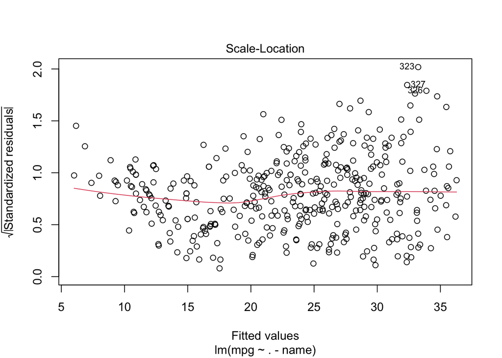

```r
plot(x = reg1, which = 3)
```

This graph shows the relationship between the fitted value of $y$ (denoted by $\hat{y}$) and the standardized residuals. Do not worry about the standardized residuals beyond the fact that it is simply the residuals re-scaled so that it has a standard deviation of 1 (we can do this because we only care about the spread of the residuals and not their absolute values). The `which = 3` command gets us the above graph, and for details you can Google it for some documentation on what the other numbers do.

Just by staring at the plot, we can already see that the variance does not seem constant. As the fitted value increases, the variance of the residuals increases as well. This points us to a potential heteroskedasticity problem. Another way to show this is to do the following:

```r
ncvTest(reg1)
```

```
## Non-constant Variance Score Test
## Variance formula: ~ fitted.values
## Chisquare = 29.66542, Df = 1, p = 5.1343e-08
```

The `ncvTest` function is from the `car` package. It stands for non-constant variance test. You do not need to know the details, but it basically runs a regression of the residuals on the fitted values. As we can see in the results, the $p$ value is really small, suggesting that we should reject the null hypothesis (that the variance is constant).

At this point, you may wonder what problems does heteroskedasticity cause. In short, it makes the standard errors of the $\beta$’s unreliable. This is a big problem since if we get the standard errors wrong, then results from hypothesis testing cannot be trusted. You will learn this more formally in a econometric theory class, but this is the rough idea.

So how do we correct for it? The `lmtest` package provides a simple way with the following command:

```r
coeftest(reg1, vcov = vcovHC)
```

```
##
## t test of coefficients:
##
##                 Estimate  Std. Error t value  Pr(>|t|)
## (Intercept)  -1.7955e+01  5.1461e+00 -3.4890 0.0005413 ***
## cylinders    -4.8971e-01  3.1487e-01 -1.5553 0.1207049
## displacement  2.3979e-02  9.0831e-03  2.6399 0.0086317 **
## horsepower   -1.8183e-02  1.4863e-02 -1.2234 0.2219134
## weight       -6.7104e-03  8.6734e-04 -7.7367 9.138e-14 ***
## acceleration  7.9103e-02  1.2825e-01  0.6168 0.5377431
## year          7.7703e-01  5.4342e-02 14.2989 < 2.2e-16 ***
## origin2       2.6300e+00  6.6565e-01  3.9510 9.265e-05 ***
## origin3       2.8532e+00  5.5759e-01  5.1171 4.919e-07 ***
## ---
## Signif. codes:  0 '***' 0.001 '**' 0.01 '*' 0.05 '.' 0.1 ' ' 1
```

Compare to our original result:

```r
summary(reg1)
```

```
##
## Call:
## lm(formula = mpg ~ . - name, data = auto1)
##
## Residuals:
##     Min      1Q  Median      3Q     Max
## -9.0095 -2.0785 -0.0982  1.9856 13.3608
##
## Coefficients:
##                Estimate Std. Error t value Pr(>|t|)
## (Intercept)  -1.795e+01  4.677e+00  -3.839 0.000145 ***
## cylinders    -4.897e-01  3.212e-01  -1.524 0.128215
## displacement  2.398e-02  7.653e-03   3.133 0.001863 **
## horsepower   -1.818e-02  1.371e-02  -1.326 0.185488
## weight       -6.710e-03  6.551e-04 -10.243  < 2e-16 ***
## acceleration  7.910e-02  9.822e-02   0.805 0.421101
## year          7.770e-01  5.178e-02  15.005  < 2e-16 ***
## origin2       2.630e+00  5.664e-01   4.643 4.72e-06 ***
## origin3       2.853e+00  5.527e-01   5.162 3.93e-07 ***
## ---
## Signif. codes:  0 '***' 0.001 '**' 0.01 '*' 0.05 '.' 0.1 ' ' 1
##
## Residual standard error: 3.307 on 383 degrees of freedom
## Multiple R-squared:  0.8242, Adjusted R-squared:  0.8205
## F-statistic: 224.5 on 8 and 383 DF,  p-value: < 2.2e-16
```

The command `vcov = vcovHC` asks R to return the heteroskedasticity-consistent standard errors. We observe that the standard errors for each coefficient has changed. This did not affect the significance across the two cases, but I would argue that this is more accidental than substantial. We could very well have had a different result entirely.

## 7.2 Autocorrelation

Autocorrelation refers to the fact that the residuals from the regression are correlated with each other, most likely by some groups. For example, we mentioned previously that when regressing departure delays on a set of variables using the `nycflights13` dataset, we should be concerned that a particular airline or destination exhibits idiosyncrasies. These idiosyncrasies are not captured by any of the regressors and are specific to each airline or destination, and therefore they end up in the error term, making the residuals in that group correlated with each other.

So how do we test for autocorrelation? In the `lmtest` package, there is a function `dwtest`. This function carries out the so-called Durbin-Watson test for autocorrelation. Put it simply, it is a test of the correlation between two consecutive standard errors. Let’s apply it to the above regression:

```r
dwtest(reg1)
```

```
##
##  Durbin-Watson test
##
## data:  reg1
## DW = 1.2914, p-value = 2.835e-13
## alternative hypothesis: true autocorrelation is greater than 0
```

This suggests that we have a strong autocorrelation among the residuals. The DW test has many limitations, but it’s a first indication. In the future you will learn more ways to detect autocorrelation. The problem with autocorrelation is similar to that of heteroskedasticity, in that it affects the accuracy of the standard errors. So how can we deal with it? The most commonly used method is to cluster the standard errors at a level higher than the unit of observation. For example, we may expect that cars from different origins or years to have idiosyncrasies that cause them to have correlated standard errors. Practically, people have found that clustering needs to have at least 20 units, and preferably 30-50. Clearly neither `year` nor `origin` satisfies this requirement. However, what we can do is to generate a new identifier that is the combination of both `year` and `origin`. The simplest way to create this new variable is to multiply `origin` with `year`:

```r
auto2 <- mutate(Auto, origin_year = origin*year)
auto2$origin <- as.factor(auto2$origin)
```

Now let’s check the number of unique `origin_year` identifier:

```r
length(unique(auto2$origin_year))
```

```
## [1] 39
```

We get 39, which is good enough. Let’s recap what we are doing here. Basically, we are saying that for the observed cars, each origin-year combination may exhibit idiosyncrasies that make all observations within this combination have residuals that are correlated with each other. In order to solve it, we can “cluster” the standard errors at the origin-year level - recalculating the standard errors based on the assumption that errors in the same group are correlated with each other. Again, there is no need to know the detailed math, but this is the general idea.

Now let’s apply the clustered standard errors:

```r
reg2 <- lm(mpg ~ . - name - origin_year, data = auto2)
coeftest(reg2, vcov = vcovCL, cluster = ~ origin_year)
```

```
##
## t test of coefficients:
##
##                 Estimate  Std. Error t value  Pr(>|t|)
## (Intercept)  -1.7955e+01  8.1407e+00 -2.2055 0.0280091 *
## cylinders    -4.8971e-01  3.5709e-01 -1.3714 0.1710506
## displacement  2.3979e-02  1.0722e-02  2.2365 0.0258948 *
## horsepower   -1.8183e-02  1.4489e-02 -1.2550 0.2102554
## weight       -6.7104e-03  9.6583e-04 -6.9478 1.602e-11 ***
## acceleration  7.9103e-02  1.3904e-01  0.5689 0.5697369
## year          7.7703e-01  8.3185e-02  9.3409 < 2.2e-16 ***
## origin2       2.6300e+00  1.0380e+00  2.5336 0.0116872 *
## origin3       2.8532e+00  8.4413e-01  3.3801 0.0007991 ***
## ---
## Signif. codes:  0 '***' 0.001 '**' 0.01 '*' 0.05 '.' 0.1 ' ' 1
```

Compare to our initial results:

```r
coeftest(reg1, vcov = vcovHC)
```

```
##
## t test of coefficients:
##
##                 Estimate  Std. Error t value  Pr(>|t|)
## (Intercept)  -1.7955e+01  5.1461e+00 -3.4890 0.0005413 ***
## cylinders    -4.8971e-01  3.1487e-01 -1.5553 0.1207049
## displacement  2.3979e-02  9.0831e-03  2.6399 0.0086317 **
## horsepower   -1.8183e-02  1.4863e-02 -1.2234 0.2219134
## weight       -6.7104e-03  8.6734e-04 -7.7367 9.138e-14 ***
## acceleration  7.9103e-02  1.2825e-01  0.6168 0.5377431
## year          7.7703e-01  5.4342e-02 14.2989 < 2.2e-16 ***
## origin2       2.6300e+00  6.6565e-01  3.9510 9.265e-05 ***
## origin3       2.8532e+00  5.5759e-01  5.1171 4.919e-07 ***
## ---
## Signif. codes:  0 '***' 0.001 '**' 0.01 '*' 0.05 '.' 0.1 ' ' 1
```

In actual research, thinking about whether to cluster standard errors, and at what levels the cluster should be, is an essential skill to be learned. You will need to justify your choice of levels. Some are easier to explain, for example if you regress future income on school grades of a particular school, it is quite likely that the standard errors are correlated within a given class. Others are more difficult to explain. For the above example, using origin-year seems appropriate, but it is still subject to debate.

## 7.3 Instrumental Variable

Most of the discussions on linear regression centers around the third GM assumption, that the error term has zero mean conditional on the regressors. This condition is often referred to as the exogeneity condition, and may be violated by a number of reasons, resulting in endogeneity. Previously, we discussed reasons such as reverse causality and selection bias. Another reason is omitted variable - variables that can affect both $y$ and $x$’s are not included and therefore end up in the error term, making the $x$’s correlated with the error terms. Furthermore, measurement errors on the $x$’s can also result in the $x$’s being endogenous.

There are many ways in which the exogeneity condition can be violated. We are not covering all of them here, and we do not discuss the mathematics behind them. However, there are ways to mitigate these problems and they can be done in R.

The most frequently used method is called the instrumental variable (IV). Basically, once you’ve identified an endogenous variable, you have to find another variable (the instrument) that affects the dependent variable $y$ to replace the endogenous variable $x$. However, we still want to know the coefficient on $x$, so the instrument has to be such that it affects $y$ only through $x$ and through no other means. Let’s use an example to demonstrate what this means. First, we load a new dataset (using `read_dta` from the `haven` package under the `tidyverse` package):

```r
griliches <- read_dta("griliches.dta")
```

This dataset is from Griliches (1970). The author models wage (`lw`) on several regressors:

```r
griliches$year <- as.factor(griliches$year)
reg3 <- lm(lw ~ s + expr + tenure + rns + smsa + year + iq, data = griliches)
summary(reg3)
```

```
##
## Call:
## lm(formula = lw ~ s + expr + tenure + rns + smsa + year + iq,
##     data = griliches)
##
## Residuals:
##     Min      1Q  Median      3Q     Max
## -1.1861 -0.2137  0.0204  0.2179  1.1468
##
## Coefficients:
##              Estimate Std. Error t value Pr(>|t|)
## (Intercept)  4.235357   0.113349  37.366  < 2e-16 ***
## s            0.061955   0.007279   8.512  < 2e-16 ***
## expr         0.030839   0.006510   4.737 2.60e-06 ***
## tenure       0.042163   0.007481   5.636 2.47e-08 ***
## rns         -0.096293   0.027547  -3.496 0.000501 ***
## smsa         0.132899   0.026576   5.001 7.13e-07 ***
## year67      -0.054209   0.047852  -1.133 0.257641
## year68       0.080581   0.044895   1.795 0.073080 .
## year69       0.207592   0.043860   4.733 2.65e-06 ***
## year70       0.228224   0.048799   4.677 3.46e-06 ***
## year71       0.222691   0.043095   5.167 3.05e-07 ***
## year73       0.322875   0.040657   7.941 7.37e-15 ***
## iq           0.002712   0.001031   2.630 0.008727 **
## ---
## Signif. codes:  0 '***' 0.001 '**' 0.01 '*' 0.05 '.' 0.1 ' ' 1
##
## Residual standard error: 0.3264 on 745 degrees of freedom
## Multiple R-squared:  0.4301, Adjusted R-squared:  0.421
## F-statistic: 46.86 on 12 and 745 DF,  p-value: < 2.2e-16
```

```r
coeftest(reg3, vcov = vcovHC)
```

```
##
## t test of coefficients:
##
##               Estimate Std. Error t value  Pr(>|t|)
## (Intercept)  4.2353569  0.1236033 34.2657 < 2.2e-16 ***
## s            0.0619548  0.0076839  8.0630 2.967e-15 ***
## expr         0.0308395  0.0067239  4.5865 5.285e-06 ***
## tenure       0.0421631  0.0073201  5.7599 1.231e-08 ***
## rns         -0.0962935  0.0285489 -3.3729 0.0007822 ***
## smsa         0.1328993  0.0263778  5.0383 5.899e-07 ***
## year67      -0.0542095  0.0462888 -1.1711 0.2419272
## year68       0.0805808  0.0438262  1.8386 0.0663651 .
## year69       0.2075915  0.0412517  5.0323 6.080e-07 ***
## year70       0.2282237  0.0522304  4.3696 1.422e-05 ***
## year71       0.2226915  0.0422075  5.2761 1.732e-07 ***
## year73       0.3228747  0.0402907  8.0136 4.297e-15 ***
## iq           0.0027121  0.0011012  2.4629 0.0140082 *
## ---
## Signif. codes:  0 '***' 0.001 '**' 0.01 '*' 0.05 '.' 0.1 ' ' 1
```

The variables stand for, from first to last, years of schooling, experience, job-tenure, indicator for residency in the South, indicator for urban versus rural, year dummies and IQ score.

Now, what is the concern here? The author wants to know how ability affects wage, but since ability is unobservable, the best they can do is to use IQ score to proxy for ability. IQ scores can be considered as a mismeasured version of ability. We mentioned that measurement error can cause endogeneity problems in regression, so this is an example of that.

So how do we solve this problem with instrumental variable? We need to find one or more variables that affect the worker’s wage through nothing but ability. Note that you need at least as many IVs as your endogenous variable, and in our case we need at least one. However, you can have more than one instruments for one endogenous variable. When doing the IV this way, it is called the two stage least squares estimation.

The author proposed the following four variables to instrument for IQ (the mismeasured version of ability): `med` (mothers level of education), `kww` (score on another standardized test), `age` (the worker’s age in year) and `mrt` (indicator of marital status).

Do these variables seem like they affect wage only through ability? Probably not, especially for `med` and `mrt`. Mother’s education level may be associated with the mother’s social connection, which could potentially affect the child’s social connection and hence the wage. Being married may affect one’s wage through a variety of ways. Age may also affect a worker’s wage through things other than ability, even if we are already controlling for experience. Anyway, let’s see how instrumental variable estimation is implemented in R. First, let’s do what the author did and include all four instruments in the regression (using `ivreg` from the `AER` package):

```r
reg4 <- ivreg(lw ~ s + expr + tenure + rns + smsa + year + iq | s + expr + tenure + rns + smsa + year
              + med + mrt + age + kww, data = griliches)
summary(reg4)
```

```
##
## Call:
## ivreg(formula = lw ~ s + expr + tenure + rns + smsa + year +
##     iq | s + expr + tenure + rns + smsa + year + med + mrt +
##     age + kww, data = griliches)
##
## Residuals:
##      Min       1Q   Median       3Q      Max
## -1.17127 -0.21892  0.01988  0.21706  1.14404
##
## Coefficients:
##               Estimate Std. Error t value Pr(>|t|)
## (Intercept)  4.3995501  0.2708771  16.242  < 2e-16 ***
## s            0.0691759  0.0130490   5.301 1.52e-07 ***
## expr         0.0298660  0.0066970   4.460 9.48e-06 ***
## tenure       0.0432738  0.0076934   5.625 2.63e-08 ***
## rns         -0.1035897  0.0297371  -3.484 0.000524 ***
## smsa         0.1351148  0.0268889   5.025 6.31e-07 ***
## year67      -0.0525980  0.0481067  -1.093 0.274589
## year68       0.0794686  0.0451078   1.762 0.078522 .
## year69       0.2108962  0.0443153   4.759 2.34e-06 ***
## year70       0.2386338  0.0514161   4.641 4.09e-06 ***
## year71       0.2284609  0.0441236   5.178 2.89e-07 ***
## year73       0.3258944  0.0410718   7.935 7.74e-15 ***
## iq           0.0001747  0.0039374   0.044 0.964631
## ---
## Signif. codes:  0 '***' 0.001 '**' 0.01 '*' 0.05 '.' 0.1 ' ' 1
##
## Residual standard error: 0.3277 on 745 degrees of freedom
## Multiple R-Squared: 0.4255,  Adjusted R-squared: 0.4163
## Wald test: 45.91 on 12 and 745 DF,  p-value: < 2.2e-16
```

```r
coeftest(reg4, vcov = vcovHC)
```

```
##
## t test of coefficients:
##
##                Estimate  Std. Error t value  Pr(>|t|)
## (Intercept)  4.39955007  0.29718314 14.8042 < 2.2e-16 ***
## s            0.06917592  0.01360847  5.0833 4.696e-07 ***
## expr         0.02986602  0.00687596  4.3435 1.596e-05 ***
## tenure       0.04327376  0.00757973  5.7091 1.640e-08 ***
## rns         -0.10358970  0.03035065 -3.4131  0.000677 ***
## smsa         0.13511483  0.02685853  5.0306 6.133e-07 ***
## year67      -0.05259801  0.04666569 -1.1271  0.260053
## year68       0.07946861  0.04362103  1.8218  0.068887 .
## year69       0.21089615  0.04162852  5.0661 5.124e-07 ***
## year70       0.23863382  0.05416081  4.4060 1.207e-05 ***
## year71       0.22846092  0.04348153  5.2542 1.943e-07 ***
## year73       0.32589442  0.04134522  7.8823 1.142e-14 ***
## iq           0.00017465  0.00422764  0.0413  0.967058
## ---
## Signif. codes:  0 '***' 0.001 '**' 0.01 '*' 0.05 '.' 0.1 ' ' 1
```

So we can see that IQ use to have a coefficient that is significant at 5%, but no longer. Should we trust this result? Well, remember that instruments need to affect the outcome through the endogenous variable only. What we can do is to regress IQ on all the instruments and see which of the instruments are actually relevant:

```r
reg5 <- lm(iq ~ med + mrt + age + kww, data = griliches)
coeftest(reg5, vcov = vcovHC)
```

```
##
## t test of coefficients:
##
##              Estimate Std. Error t value  Pr(>|t|)
## (Intercept) 67.737731   3.883927 17.4405 < 2.2e-16 ***
## med          0.996053   0.167421  5.9494 4.121e-09 ***
## mrt         -2.227838   1.027758 -2.1677    0.0305 *
## age          0.291819   0.192472  1.5162    0.1299
## kww          0.547538   0.075088  7.2920 7.745e-13 ***
## ---
## Signif. codes:  0 '***' 0.001 '**' 0.01 '*' 0.05 '.' 0.1 ' ' 1
```

So it seems like age is not a very relevant instrument. If we drop `age`, we get the following results for the IV regression:

```r
reg6 <- ivreg(lw ~ s + expr + tenure + rns + smsa + year + iq | s + expr + tenure + rns + smsa + year
              + med + mrt + kww, data = griliches)
summary(reg6)
```

```
##
## Call:
## ivreg(formula = lw ~ s + expr + tenure + rns + smsa + year +
##     iq | s + expr + tenure + rns + smsa + year + med + mrt +
##     kww, data = griliches)
##
## Residuals:
##      Min       1Q   Median       3Q      Max
## -1.35025 -0.24340  0.01463  0.22505  1.26788
##
## Coefficients:
##              Estimate Std. Error t value Pr(>|t|)
## (Intercept)  3.394529   0.344991   9.839  < 2e-16 ***
## s            0.024976   0.016258   1.536  0.12492
## expr         0.035824   0.007419   4.829 1.67e-06 ***
## tenure       0.036475   0.008522   4.280 2.11e-05 ***
## rns         -0.058930   0.033537  -1.757  0.07930 .
## smsa         0.121554   0.029590   4.108 4.44e-05 ***
## year67      -0.062462   0.052798  -1.183  0.23718
## year68       0.086277   0.049495   1.743  0.08172 .
## year69       0.190669   0.048739   3.912 9.99e-05 ***
## year70       0.174914   0.057485   3.043  0.00243 **
## year71       0.193146   0.048791   3.959 8.26e-05 ***
## year73       0.307411   0.045168   6.806 2.07e-11 ***
## iq           0.015706   0.005098   3.081  0.00214 **
## ---
## Signif. codes:  0 '***' 0.001 '**' 0.01 '*' 0.05 '.' 0.1 ' ' 1
##
## Residual standard error: 0.3595 on 745 degrees of freedom
## Multiple R-Squared: 0.3087,  Adjusted R-squared: 0.2976
## Wald test: 38.95 on 12 and 745 DF,  p-value: < 2.2e-16
```

```r
coeftest(reg6, vcov = vcovHC)
```

```
##
## t test of coefficients:
##
##               Estimate Std. Error t value  Pr(>|t|)
## (Intercept)  3.3945292  0.3576959  9.4900 < 2.2e-16 ***
## s            0.0249756  0.0163881  1.5240  0.127931
## expr         0.0358245  0.0077417  4.6274 4.366e-06 ***
## tenure       0.0364752  0.0081638  4.4679 9.125e-06 ***
## rns         -0.0589297  0.0334727 -1.7605  0.078728 .
## smsa         0.1215536  0.0293215  4.1455 3.780e-05 ***
## year67      -0.0624618  0.0506993 -1.2320  0.218336
## year68       0.0862766  0.0512393  1.6838  0.092640 .
## year69       0.1906686  0.0469083  4.0647 5.321e-05 ***
## year70       0.1749140  0.0609645  2.8691  0.004233 **
## year71       0.1931464  0.0465559  4.1487 3.729e-05 ***
## year73       0.3074108  0.0437798  7.0217 4.941e-12 ***
## iq           0.0157064  0.0052299  3.0032  0.002761 **
## ---
## Signif. codes:  0 '***' 0.001 '**' 0.01 '*' 0.05 '.' 0.1 ' ' 1
```

With the updated set of instruments, IQ now has a significant coefficient. How should we interpret this? It just shows how difficult selecting good instruments is. The results can be very sensitive so you need good justification for your instruments. There are more formal tests on instrument validity and relevance, and you will learn them in the econometrics course. For now, just be aware of this problem, and hopefully when you come across them in the future, these codes will be useful as a baseline result.

# 8 Logistic Regression

So far we have run regression using $y$ variables that are continuous. But sometimes our dependent variable may be categorical - it is either 0 or 1 (no or yes, true or false, isn’t or is). We can still do linear regression on this type of $y$, but the interpretation is not so straightforward. This is because in linear regression, the coefficients on the independent variables are not bound by anything, so it is possible (and quite likely) that you will end up in the situation where the predicted $y$ is negative or over 1. In other words, linear models are not terribly suited for this purpose.

This is where we call for the help of the logistic models. We can model $p(x)$ using a function that gives outputs between 0 and 1 for all values of $x$. Many functions meet this description. In logistic regression, we use the logistic function:

$$p(x)=\frac{e^{\beta_{0}+\beta_{1} x}}{1+e^{\beta_{0}+\beta_{1}x}}$$

No need to worry about the math here. Just be aware that this regression takes the values of the $x$’s and returns the probability of $y$ being 1 that lies strictly between 0 and 1.

## 8.1 Running Logistic Regression

Let’s load a dataset and see what these all mean in practice. In the package `ISLR`, there is a simulated dataset called `Default` that has information on ten thousand customers such as whether the customer defaulted, is a student, the average balance carried by the customer and the income of the customer:

```r
default <- as_tibble(ISLR::Default)
```

Let’s add a bit of machine learning flavor into the study of logistic regression. We can split the sample into two parts randomly, one called `train`, which we use to run the regression (train the algorithm), and the other `test`, which we use to check if the estimated parameters offer good predictions out of the sample:

```r
set.seed(1)
sample <- sample(c(TRUE, FALSE), nrow(default), replace = TRUE, prob = c(0.6, 0.4))
train <- default[sample, ]
test <- default[!sample, ]
```

The function to run logistic regression is `glm`, standing for generalized linear model. Let’s regress default on the variable balance first:

```r
reg7 <- glm(default ~ balance, family = binomial, data = train)
summary(reg7)
```

```
##
## Call:
## glm(formula = default ~ balance, family = binomial, data = train)
##
## Deviance Residuals:
##     Min       1Q   Median       3Q      Max
## -2.4239  -0.1340  -0.0509  -0.0174   3.8641
##
## Coefficients:
##               Estimate Std. Error z value Pr(>|z|)
## (Intercept) -11.348054   0.517281  -21.94   <2e-16 ***
## balance       0.005952   0.000316   18.83   <2e-16 ***
## ---
## Signif. codes:  0 '***' 0.001 '**' 0.01 '*' 0.05 '.' 0.1 ' ' 1
##
## (Dispersion parameter for binomial family taken to be 1)
##
##     Null deviance: 1728.97  on 6033  degrees of freedom
## Residual deviance:  918.22  on 6032  degrees of freedom
## AIC: 922.22
##
## Number of Fisher Scoring iterations: 8
```

Now we can see that `balance` has a highly significant coefficient that is positive, meaning that higher outstanding balance represents a higher probability of default, which is not surprising. However, one should be cautious about directly interpreting the value of the coefficient, as it does not really represent increases or decreases in probability. For now, it is sufficient for us to look at the sign of the coefficient only. Here we specify `family = binomial` to tell R to run the logistic model instead of other generalized linear models. Logistic regressions are estimated with maximum likelihood method.

What does the logistic regression results look like? We can plot the predicted default probability using the following command:

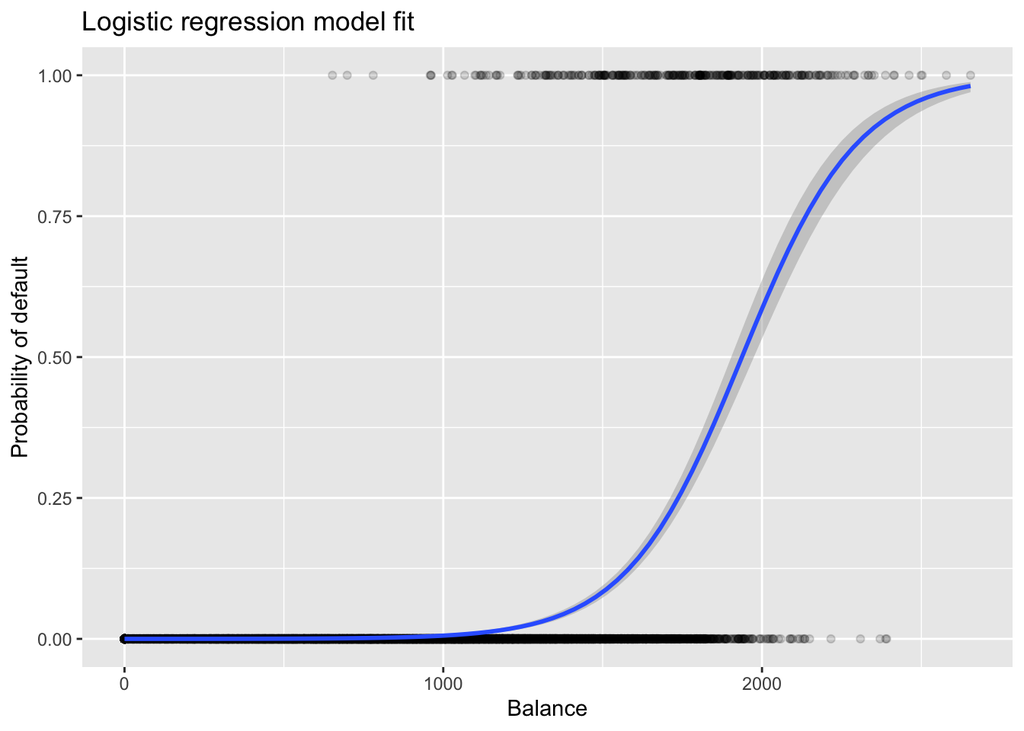

```r
default <- mutate(default, prob = ifelse(default == "Yes", 1, 0))
ggplot(default, aes(balance, prob)) +
geom_point(alpha = .15) +
geom_smooth(method = "glm", method.args = list(family = "binomial")) +
ggtitle("Logistic regression model fit") +
xlab("Balance") +
ylab("Probability of default")
```

We first encode the “Yes” and “No” in the dataset into 1 and 0 so that we can plot them. Basically, this graph tells us that with an outstanding balance of 1000 dollars or less, the probability of default is practically 0. However, from 1000 dollars upwards, the probability of default increases dramatically. This graph nicely visualizes what the logistic regression does - it offers a predication of the outcome based on the independent variables.

We can change the independent variable to another one or include more of them:

```r
reg8 <- glm(default ~ ., family = binomial, data = train)
summary(reg8)
```

```
##
## Call:
## glm(formula = default ~ ., family = binomial, data = train)
##
## Deviance Residuals:
##     Min       1Q   Median       3Q      Max
## -2.6059  -0.1297  -0.0488  -0.0162   3.8397
##
## Coefficients:
##               Estimate Std. Error z value Pr(>|z|)
## (Intercept) -1.172e+01  6.853e-01 -17.101   <2e-16 ***
## studentYes  -4.701e-01  3.069e-01  -1.532    0.126
## balance      6.156e-03  3.295e-04  18.683   <2e-16 ***
## income       7.185e-06  1.071e-05   0.671    0.503
## ---
## Signif. codes:  0 '***' 0.001 '**' 0.01 '*' 0.05 '.' 0.1 ' ' 1
##
## (Dispersion parameter for binomial family taken to be 1)
##
##     Null deviance: 1728.97  on 6033  degrees of freedom
## Residual deviance:  906.56  on 6030  degrees of freedom
## AIC: 914.56
##
## Number of Fisher Scoring iterations: 8
```

We should be cautious about the results here. Once we have added more regressors, the problem of the regressors being correlated arises. This may confound our findings. We won’t go into the details for now, but just be aware that it can be a lot harder to interpret results with multiple regressors than just a single regressor.

## 8.2 Testing Predictions

Let’s run one more model with a different variable `student`:

```r
reg9 <- glm(default ~ student, family = binomial, data = train)
summary(reg9)
```

```
##
## Call:
## glm(formula = default ~ student, family = binomial, data = train)
##
## Deviance Residuals:
##     Min       1Q   Median       3Q      Max
## -0.2941  -0.2941  -0.2403  -0.2403   2.6680
##
## Coefficients:
##             Estimate Std. Error z value Pr(>|z|)
## (Intercept) -3.53021    0.09185 -38.434  < 2e-16 ***
## studentYes   0.41130    0.15016   2.739  0.00616 **
## ---
## Signif. codes:  0 '***' 0.001 '**' 0.01 '*' 0.05 '.' 0.1 ' ' 1
##
## (Dispersion parameter for binomial family taken to be 1)
##
##     Null deviance: 1729.0  on 6033  degrees of freedom
## Residual deviance: 1721.7  on 6032  degrees of freedom
## AIC: 1725.7
##
## Number of Fisher Scoring iterations: 6
```

While `student` is significant at 5%, `income` is not. Regardless, let’s keep all the results. Now we use each model to predict whether a person defaults using the `test` sample, and compare the results:

```r
test1 <- predict(reg7, newdata = test, type = "response")
test2 <- predict(reg9, newdata = test, type = "response")
test3 <- predict(reg8, newdata = test, type = "response")
```

We use `type = "response"` to tell R to return the predicted probability of default. Now what we have are three vectors, each containing the predicted probability of default for the observations in the `test` sample, based on the three different models. From here it is not too clear which one is better, so we need to convert these probabilities into actual, solid prediction. To do this, we need to pick a threshold, say 50%, such that if the model predicts a probability of default greater than 50%, we count this person as being predicted to default. Let’s see how accurate our predictions are:

```r
model1 <- prop.table(table(test$default, test1 > 0.5))
model2 <- prop.table(table(test$default, test2 > 0.5))
model3 <- prop.table(table(test$default, test3 > 0.5))
list(model1, model2, model3)
```

```
## [[1]]
##
##             FALSE        TRUE
##   No  0.957387796 0.008068583
##   Yes 0.021432173 0.013111447
##
## [[2]]
##
##            FALSE
##   No  0.96545638
##   Yes 0.03454362
##
## [[3]]
##
##            FALSE       TRUE
##   No  0.95763994 0.00781644
##   Yes 0.02118003 0.01336359
```

Here, “No” and “Yes” mean no default and defaulted respectively, while “False” and “True” mean predicted to not default and predicted to default respectively. Therefore, we can see that for the first model, we have a 95.7% true negative rate - the person did not default and we correctly predicted it. For `model1` and `model3`, the type I and II errors are very small. For `model2`, the model never predicts that the person will default, so despite a high rate of true negative, it does not seem like the best model out of the three. Similar to linear regression, we also need to be aware of potential endogeneity problems in logistic regression, but we will save it for the future.

# 9 Conclusion

In this part we introduced statistical inference and linear regression in R. The big takeaway here is linear regression. Linear regressions can also be made to predict outcomes, and it is also one of the most widely used algorithms in machine learning. However, as economists, we care primarily about exogeneity - whether the model gives a causal interpretation. Therefore, in future econometrics classes, you will be studying a lot of ways to deal with endogeneity. We introduced a few solutions to those problems, and you will hopefully find useful in later studies.